# Report

[figure not shown]

### Table of Content

Introduction

Report Details

Conclusion

The data for this analysis was retrieved from WeRateDogs twitter archives with some additional was retireved from their twitter page using the Twitter API and with the help of neural network (Machine Learning Algorithm) to predict the dog breeds using the images from the tweets and the data was hosted on udacity servers. 2075 records of data was gathered after wrangling (gathering, assessing and cleaning) the data and after carefully wrangling the data, the following questions where raised;

- 1. Which dog breed has the highest retweets and likes and which dog breed has the lowest retweets aand likes?
- 2. Which dog names are the top 10 most common?
- 3. Did likes and retweets from #WeRateDogs decrease or increase overtime?

Through analysis, the questions mention above where answered with clear details.

To start with, the dog breed with the highest retweets and likes from the #WeRateDog twitter data is the *Golden Retriever* among 378 dog breeds. The figure below shows a scatter plot with point labels depicting the number retweets and likes each dog has.

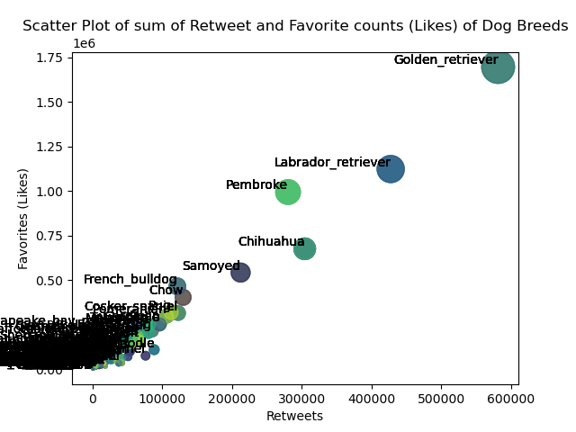

An Image of a Golden Retriever from #WeRateDog twitter page

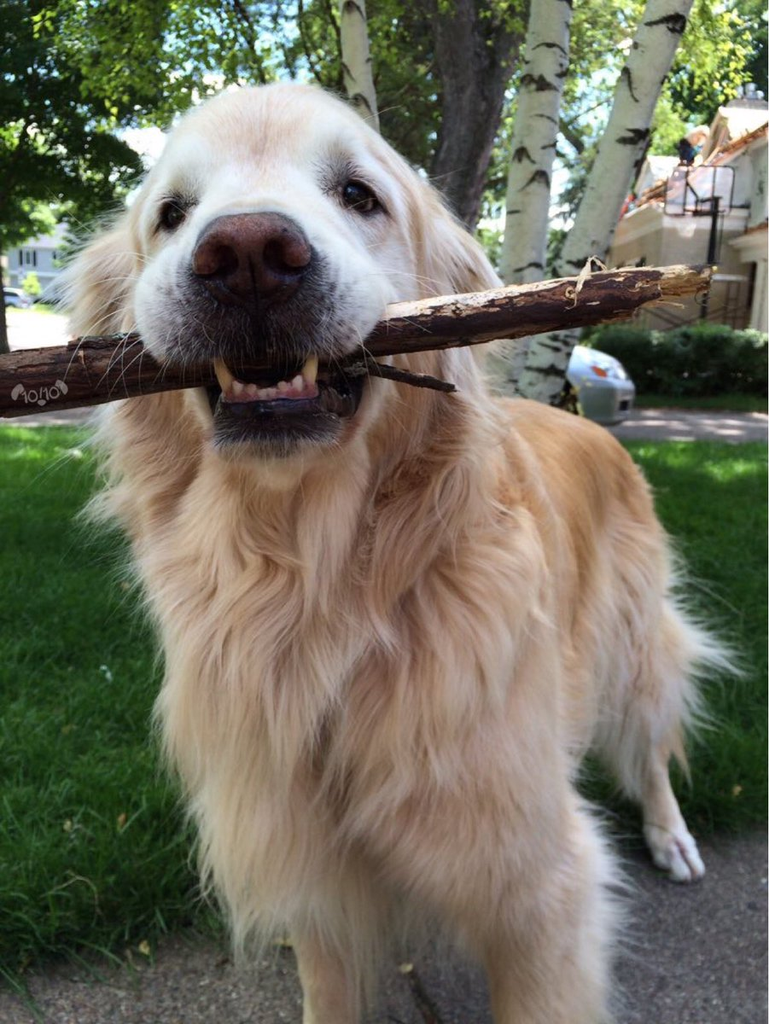

Moreover, the 10 most common dog names identified from the data are listed below with their usage count

> Charlie 11 Lucy 10 Tucker 10 Oliver 10 Penny 10 Cooper 10 Sadie 8 Bo 8 Winston 8 Lola 8

and can be seen below with their usage count

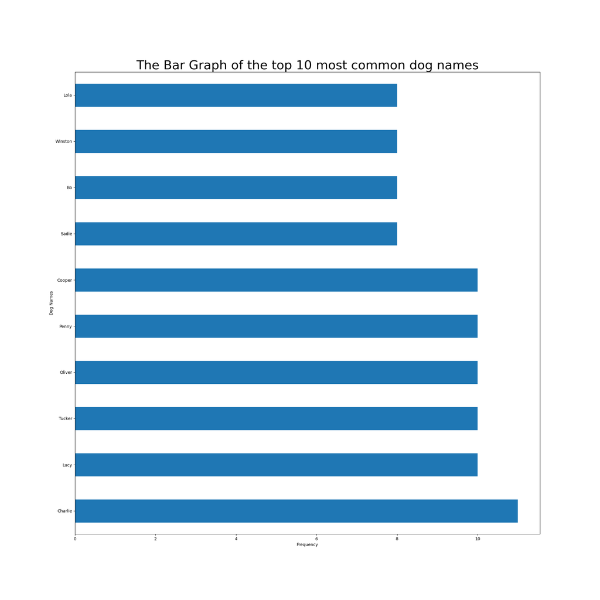

Lastly, to determine whether the engagement on the WeRateDogs page in terms of retweets and likes are increasing or decreasing, the percentage change in retweets and likes were calculated and plotted and it showed a drasctic decrease in both retweets and likes as of August 2017. Below shows various graphs of the trends in retweets and likes

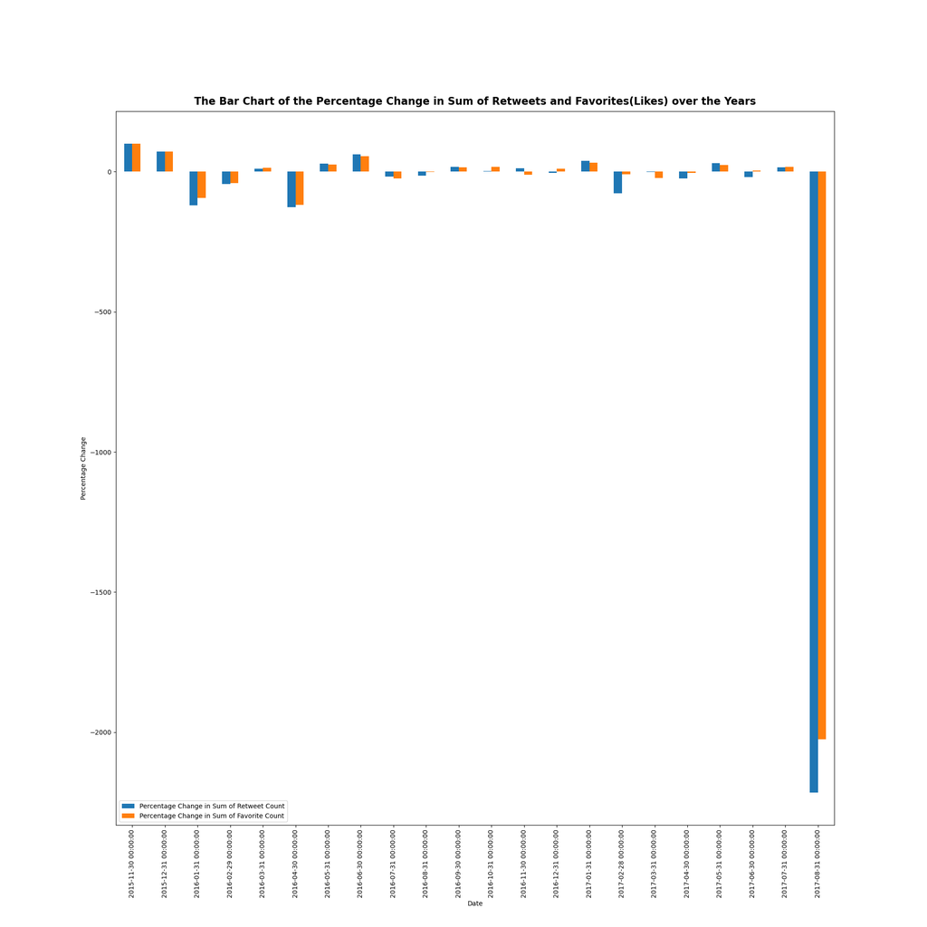

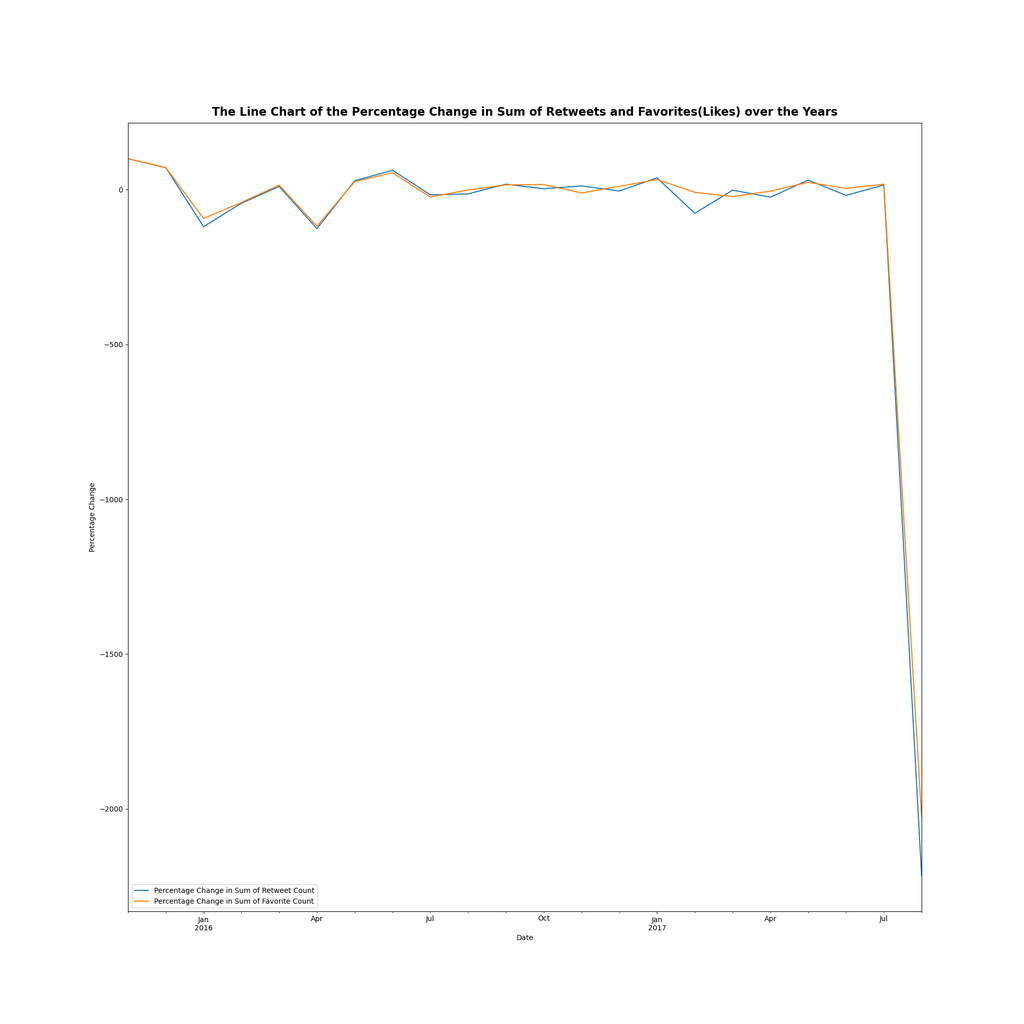

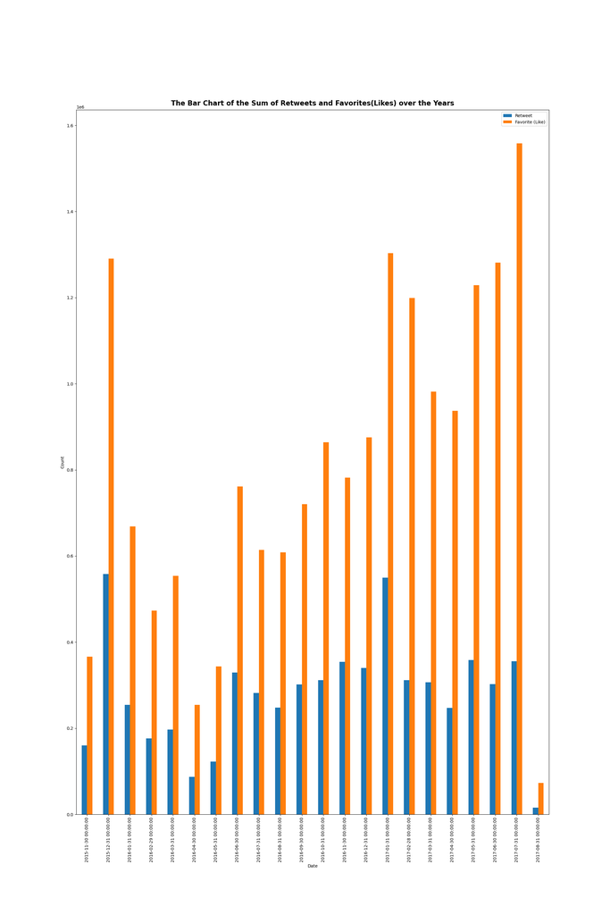

As of August 2017, the percentage change in retweet decrease from approximately 15 percent in July 2017 to 2215.71 percent in August 2017 as can be seen from the charts above.

This shows a few insights into the WeRateDogs archive. More analysis can be done to find very useful information like the relationship between the retweets and likes what is causing the fall in retweets and likes from the WeDogRate page. Though the data available can be used to show more insight into the WeRateDogs archive, some missing information like missing and invalid dog names may affect any analysis concerning dog names. Also, an attempt so determine the dog breed with the lowest retweets and likes showed that not all values predicted as dog breeds are actually correct as some are objects. For example, the dog breed with the lowest retweets turns out to be Pencil Box which clearly is an object not a dog breed, other values are Envelope Orange etc.